# Homework 1

Aleksei Parm

2022-09-08

# About

The homework is about exploring [`Carseats_mod.csv`](https://github.com/aparm/statistical-learning/blob/main/hws/hw1/Carseats_mod.csv) data set.

[GitHub](https://github.com/aparm/statistical-learning/tree/main/hws/hw1)

# Data

## Info about variables:

- Sales - Unit sales (in thousands) at each location
- CompPrice - Price charged by competitor at each location
- Income - Community income level (in thousands of dollars)
- Advertising - Local advertising budget for company at each location (in thousands of dollars)
- Population - Population size in region (in thousands)
- Price - Price company charges for car seats at each site
- ShelveLoc - A factor with levels Bad, Good and Medium indicating the quality of the shelving location for the car seats at each site
- Age -Average age of the local population
- Education -Education level at each location
- Urban - A factor with levels No and Yes to indicate whether the store is in an urban or rural location
- US - A factor to indicate whether the store is in the US or not

# Libraries

```r
#install.packages("tidyverse")
#install.packages("GGally")

library(tidyverse)
library(GGally)
```

# Exercises:

## Reading data

1. Check visually the file for presence of missing values. Use `read_delim` command (indicating the symbol for missing values if needed) to read in the data set `Carseats_mod.csv`. Make sure that all variables that, according to description, should be numeric are numeric after reading data in.

```r
carseats = read_delim("Carseats_mod.csv", delim=",", na = c(".", "NA"))
```

> Missing values in the file are presented as `.` symbol.
2. Use `summary()` function to look at summary information about variables. Do you see anything which may indicate data errors? What? How many missing values are in the data set?

```r
summary(carseats)
```

```
##      Sales          CompPrice         Income        Advertising
##  Min.   : 0.000   Min.   : 77.0   Min.   : 21.00   Min.   : 0.000
##  1st Qu.: 5.390   1st Qu.:115.0   1st Qu.: 42.75   1st Qu.: 0.000
##  Median : 7.490   Median :124.5   Median : 69.00   Median : 5.000
##  Mean   : 7.496   Mean   :124.9   Mean   : 68.66   Mean   : 6.635
##  3rd Qu.: 9.320   3rd Qu.:135.0   3rd Qu.: 91.00   3rd Qu.:12.000
##  Max.   :16.270   Max.   :175.0   Max.   :120.00   Max.   :29.000
##                   NA's   :2
##    Population        Price        ShelveLoc              Age
##  Min.   : 10.0   Min.   : 24.0   Length:400         Min.   : 9.0
##  1st Qu.:139.0   1st Qu.:100.0   Class :character   1st Qu.:39.0
##  Median :272.0   Median :117.0   Mode  :character   Median :54.0
##  Mean   :264.8   Mean   :115.8                      Mean   :53.2
##  3rd Qu.:398.5   3rd Qu.:131.0                      3rd Qu.:66.0
##  Max.   :509.0   Max.   :191.0                      Max.   :80.0
##                  NA's   :1
##    Education       Urban                US
##  Min.   :10.0   Length:400         Length:400
##  1st Qu.:12.0   Class :character   Class :character
##  Median :14.0   Mode  :character   Mode  :character
##  Mean   :13.9
##  3rd Qu.:16.0
##  Max.   :18.0
##
```

> There are 3 missing values in the data set.

## Data cleaning

3. Use `na.omit()` command to define a new data set `carseats2` where rows with missing values in the original data are left out

```r
carseats2 <- na.omit(carseats)
summary(carseats2)
```

```
##      Sales          CompPrice       Income        Advertising
##  Min.   : 0.000   Min.   : 77   Min.   : 21.00   Min.   : 0.00
##  1st Qu.: 5.360   1st Qu.:115   1st Qu.: 43.00   1st Qu.: 0.00
##  Median : 7.490   Median :125   Median : 69.00   Median : 5.00
##  Mean   : 7.472   Mean   :125   Mean   : 68.66   Mean   : 6.61
##  3rd Qu.: 9.320   3rd Qu.:135   3rd Qu.: 91.00   3rd Qu.:12.00
##  Max.   :16.270   Max.   :175   Max.   :120.00   Max.   :29.00
##    Population        Price        ShelveLoc              Age
##  Min.   : 10.0   Min.   : 24.0   Length:397         Min.   : 9.00
##  1st Qu.:139.0   1st Qu.:100.0   Class :character   1st Qu.:39.00
##  Median :272.0   Median :117.0   Mode  :character   Median :54.00
##  Mean   :264.9   Mean   :115.9                      Mean   :53.11
##  3rd Qu.:398.0   3rd Qu.:131.0                      3rd Qu.:66.00
##  Max.   :509.0   Max.   :191.0                      Max.   :80.00
##    Education        Urban                US
##  Min.   :10.00   Length:397         Length:397
##  1st Qu.:12.00   Class :character   Class :character
##  Median :14.00   Mode  :character   Mode  :character
##  Mean   :13.91
##  3rd Qu.:16.00
##  Max.   :18.00
```

> New data set contains 397 rows
4. Use `select()` command to select columns `Sales` and from `Price` to `US` from `carseats2` and apply `ggpairs()` function to the the result. Are any possible data errors visible from the output?

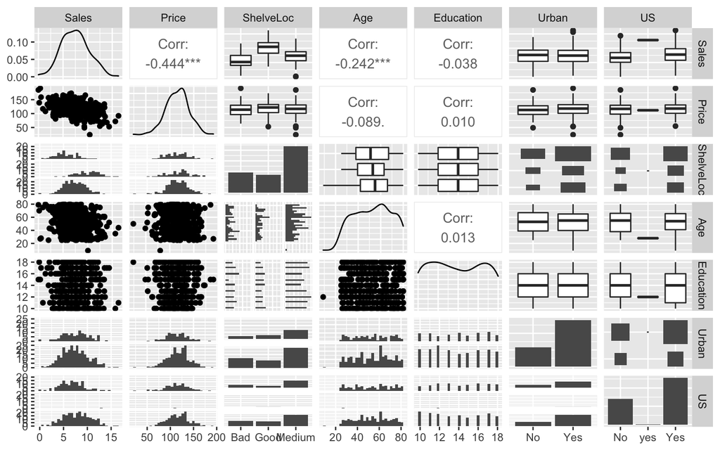

```r
carseats2 %>%
  select(Sales, Price:US) %>%
  ggpairs()
```

> `US` factor has 3 different levels: `Yes`, `No`, `yes`.

## Data transformation

5. Use `mutate()` command with `if_else()` to correct data error in one of the factor variables, store the corrected data with the same name `carseats2`

```r
levels(as.factor(carseats2$US))
```

```
## [1] "No"  "yes" "Yes"
```

```r
carseats2 <- carseats2 %>%
  mutate(US = if_else(US == "yes", "Yes", US))

levels(as.factor(carseats2$US))
```

```
## [1] "No"  "Yes"
```

> Now `US` factor has 2 levels: `Yes`, `No`.

## Summary statistics

6. Use `summarize()` command from `dplyr` package to compute a table with mean sales amount for each combination of `Urban` and `ShelveLoc`

```r
carseats2 %>%
  group_by(Urban, ShelveLoc) %>%
  summarize(MeanSales = mean(Sales))
```

```
## # A tibble: 6 × 3
## # Groups:   Urban [2]
##   Urban ShelveLoc MeanSales
##   <chr> <chr>         <dbl>
## 1 No    Bad            5.55
## 2 No    Good           9.75
## 3 No    Medium         7.24
## 4 Yes   Bad            5.52
## 5 Yes   Good          10.3
## 6 Yes   Medium         7.34
```

## Data visualization

7. Use `ggplot()` with `geom_point` to produce a scatter plot of `Price` (on x-axis) and `Sales`, color points according to shelve location. Discuss the graph - is it showing expected relationships between variables?

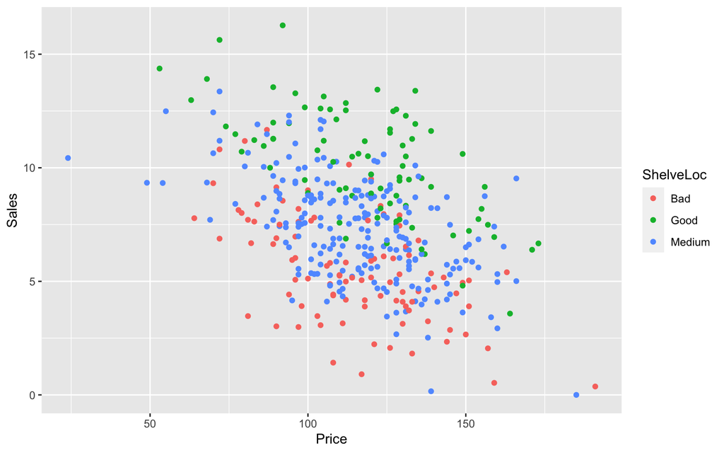

```r
ggplot(carseats2, aes(Price, Sales, color = ShelveLoc)) +
  geom_point()
```

> The scatter plot is showing relationships:
> - between `Price` and `Sales` (Car seats with lower price usually have more sales)
> - between `ShelveLoc` and `Sales` (Car seats with better shelving location usually have more sales)